# Linear Regression using a dataset with used car sales

Ioannis Vourkas

2024-11-20

# US Used cars dataset

The original data set contains 3 million real world used cars details (from kaggle [https://www.kaggle.com/datasets/ananaymital/us-used-cars-dataset/data]). However, in order to process it in R, using Python, I limited it to 30,000 values and filled the NaNs in the way described in the corresponding jupyter notebook.The measured variables:

1. **`body_type`**: The general style of the car body (e.g., sedan, SUV, truck). This variable helps classify the vehicle type based on its shape and purpose.
2. **`daysonmarket`**: The number of days the car has been listed on the market. This variable can indicate how long certain car models tend to stay unsold, which might imply demand or popularity.
3. **`fuel_type`**: The type of fuel used by the car (e.g., gasoline, diesel, electric). Different fuel types can affect a car’s operating cost, environmental impact, and market demand.
4. **`has_accidents`**: A binary indicator of whether the car has been in an accident. Cars with accident histories often have lower resale values, which makes this an important feature for pricing.
5. **`highway_fuel_economy`**: The car’s fuel efficiency on highways, usually measured in miles per gallon (mpg). This can be a key factor for buyers who prioritize fuel efficiency, particularly for long-distance driving.
6. **`horsepower`**: The power output of the car’s engine, measured in horsepower. Horsepower often influences a car’s performance and is a major consideration for buyers focused on speed and acceleration.
7. **`is_new`**: A binary variable indicating if the car is new or used. This is crucial for differentiating pricing models and expectations, as new cars typically have a premium over used ones.
8. **`make_name`**: The manufacturer or brand of the car (e.g., Toyota, Ford). Brand is often correlated with reliability, luxury status, and price.
9. **`mileage`**: The total distance the car has traveled, typically measured in miles or kilometers. Higher mileage often decreases a car’s value as it suggests more wear and tear.
10. **`price`**: The listing or sale price of the car. This is generally the target variable in pricing analyses or models for predicting car value.
11. **`seller_rating`**: The rating given to the seller, which may indicate trustworthiness or quality of service. Buyers often prefer sellers with higher ratings, as they may provide more reliable information or a better purchasing experience.
12. **`year`**: The model year of the car, indicating when it was manufactured. Older cars typically depreciate in value, while newer models may command higher prices.

## Scope

To effectively predict used car prices with a linear regression model, starting with Exploratory Data Analysis (EDA) is crucial. EDA helps you understand the relationships between the different factors (features) and the price, which will guide you in choosing and transforming the features for the predictive model.

# *Step 1: Reading and Understanding the Data*

```r
cars.df <- read.csv("cleaned_used_cars_data.csv", TRUE, ",")
dim(cars.df)
```

```
## [1] 30000    12
```

```r
str(cars.df) #Check the structure of the dataframe
```

```
## 'data.frame':    30000 obs. of  12 variables:
##  $ body_type           : chr  "SUV / Crossover" "SUV / Crossover" "Sedan" "SUV / Crossover" ...
##  $ daysonmarket        : int  522 207 1233 196 137 242 447 70 196 510 ...
##  $ fuel_type           : chr  "Gasoline" "Gasoline" "Gasoline" "Gasoline" ...
##  $ has_accidents       : chr  "unknown" "unknown" "False" "unknown" ...
##  $ highway_fuel_economy: num  27 27 23 27 27 27 34 27 27 27 ...
##  $ horsepower          : num  177 246 305 340 246 247 186 247 246 296 ...
##  $ is_new              : chr  "True" "True" "False" "True" ...
##  $ make_name           : chr  "Jeep" "Land Rover" "Subaru" "Land Rover" ...
##  $ mileage             : num  7 8 33633 11 7 ...
##  $ price               : num  23141 46500 46995 67430 48880 ...
##  $ seller_rating       : num  2.8 3 4.02 3 3 ...
##  $ year                : int  2019 2020 2016 2020 2020 2020 2019 2020 2020 2020 ...
```

```r
summary(cars.df) #Summary statistics for numerical variables
```

```
##   body_type          daysonmarket      fuel_type         has_accidents
##  Length:30000       Min.   :   0.00   Length:30000       Length:30000
##  Class :character   1st Qu.:  15.00   Class :character   Class :character
##  Mode  :character   Median :  36.00   Mode  :character   Mode  :character
##                     Mean   :  77.46
##                     3rd Qu.:  81.00
##                     Max.   :2150.00
##  highway_fuel_economy   horsepower       is_new           make_name
##  Min.   : 13.00       Min.   : 78.0   Length:30000       Length:30000
##  1st Qu.: 25.00       1st Qu.:180.0   Class :character   Class :character
##  Median : 28.00       Median :244.9   Mode  :character   Mode  :character
##  Mean   : 28.94       Mean   :244.9
##  3rd Qu.: 32.00       3rd Qu.:295.0
##  Max.   :122.00       Max.   :808.0
##     mileage           price         seller_rating        year
##  Min.   :     0   Min.   :    795   Min.   :1.000   Min.   :1940
##  1st Qu.:     8   1st Qu.:  17590   1st Qu.:3.556   1st Qu.:2017
##  Median : 22041   Median :  26150   Median :4.143   Median :2018
##  Mean   : 33633   Mean   :  29652   Mean   :4.022   Mean   :2017
##  3rd Qu.: 43746   3rd Qu.:  37513   3rd Qu.:4.556   3rd Qu.:2020
##  Max.   :341893   Max.   :1390000   Max.   :5.000   Max.   :2021
```

```r
head(cars.df) #View the first few rows
```

```
##         body_type daysonmarket fuel_type has_accidents highway_fuel_economy
## 1 SUV / Crossover          522  Gasoline       unknown                   27
## 2 SUV / Crossover          207  Gasoline       unknown                   27
## 3           Sedan         1233  Gasoline         False                   23
## 4 SUV / Crossover          196  Gasoline       unknown                   27
## 5 SUV / Crossover          137  Gasoline       unknown                   27
## 6 SUV / Crossover          242  Gasoline         False                   27
##   horsepower is_new  make_name  mileage price seller_rating year
## 1        177   True       Jeep     7.00 23141      2.800000 2019
## 2        246   True Land Rover     8.00 46500      3.000000 2020
## 3        305  False     Subaru 33632.83 46995      4.021591 2016
## 4        340   True Land Rover    11.00 67430      3.000000 2020
## 5        246   True Land Rover     7.00 48880      3.000000 2020
## 6        247   True Land Rover    12.00 66903      3.000000 2020
```

## *Step 2: Data Cleaning and Preparation*

```r
# Check for duplicates
duplicates <- cars.df[duplicated(cars.df), ]
print(paste("Number of duplicate entries:", nrow(duplicates)))
```

```
## [1] "Number of duplicate entries: 1685"
```

```r
# Remove duplicates
cars.df <- cars.df[!duplicated(cars.df), ]


# The missing values and errors have been filled in the corresponding jupyter notebook. Hence, there is no nead for extra cleaning.
```

## *Step 3: Visualizing the data*

Some example questions we might be interested in:

- What is the relationship between car mileage and price?
- Which features are most important for predicting car price?
- Which features (numerical and categorical) show the strongest correlation with car prices?

# Distributions of used car variables

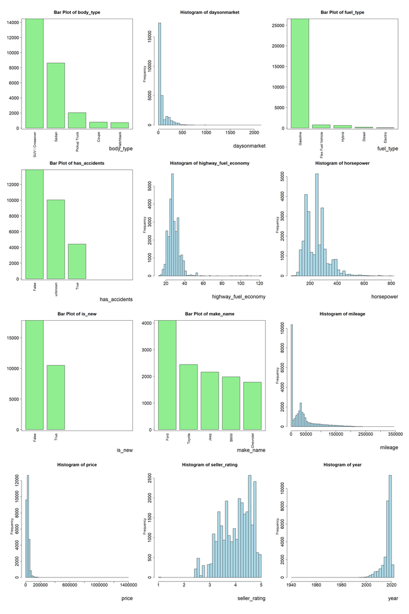

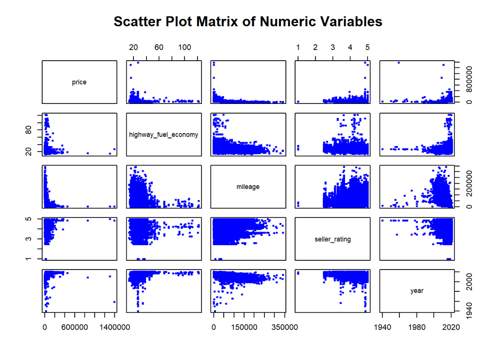

```r
# Scatter plot matrix for numeric variables in cars.df
pairs(~ price + highway_fuel_economy  +
       mileage + seller_rating + year,
      data = cars.df,
      main = "Scatter Plot Matrix of Numeric Variables",
      pch = 19,          # Use filled circles for points
      col = "blue",      # Color of points
      cex = 0.5)         # Size of points



# Ensure libraries are loaded
library(ggplot2)
```

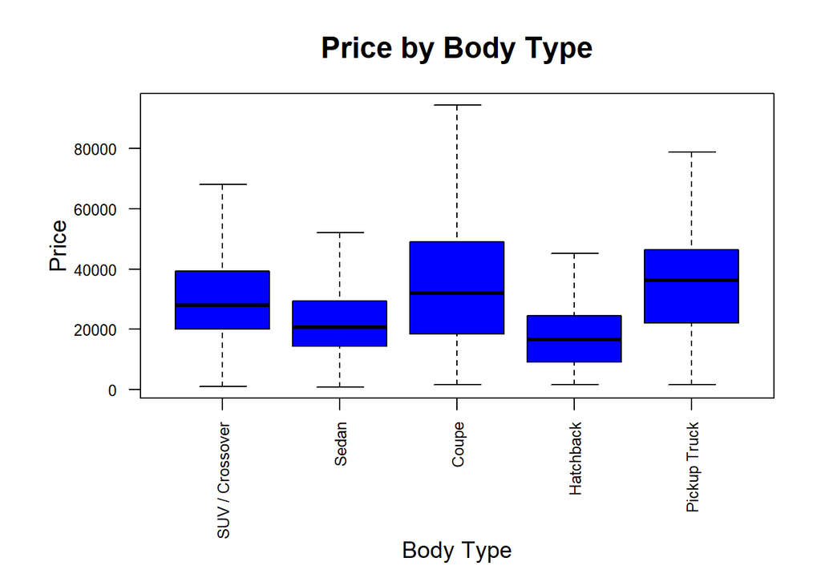

```r
# Function to filter the top 5 categories
top5_categories <- function(data, column) {
  category_counts <- table(data[[column]])
  top_categories <- names(sort(category_counts, decreasing = TRUE)[1:5])
  data[data[[column]] %in% top_categories, ]
}

# Filter data for top 5 categories for each column
top_body_type <- top5_categories(cars.df, "body_type")
top_fuel_type <- top5_categories(cars.df, "fuel_type")
top_make_name <- top5_categories(cars.df, "make_name")

# Set larger margins and spacing between boxplots
par(mar = c(8, 6, 4, 2))  # Increase bottom margin for x-axis labels

# Plot 1: Price by Body Type
boxplot(price ~ factor(body_type, levels = unique(top_body_type$body_type)),
        data = top_body_type,
        main = "Price by Body Type",
        xlab = "",
        ylab = "Price",
        col = "blue",
        las = 2,              # Rotate x-axis labels
        cex.axis = 0.8,       # Reduce size of axis text
        cex.main = 1.5,       # Larger title
        cex.lab = 1.2,        # Larger y-axis label
        outline = FALSE)      # Remove outliers for clarity
mtext("Body Type", side = 1, line = 6, cex = 1.2)  # Add x-axis label
```

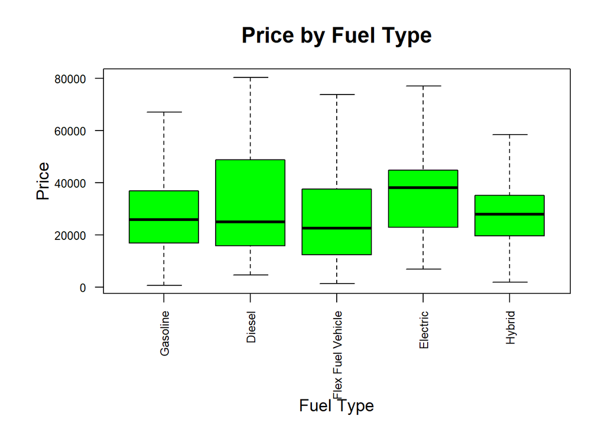

```r
# Plot 2: Price by Fuel Type
boxplot(price ~ factor(fuel_type, levels = unique(top_fuel_type$fuel_type)),
        data = top_fuel_type,
        main = "Price by Fuel Type",
        xlab = "",
        ylab = "Price",
        col = "green",
        las = 2,
        cex.axis = 0.8,
        cex.main = 1.5,
        cex.lab = 1.2,
        outline = FALSE) #  exclude outliers from the plot for better visualization
mtext("Fuel Type", side = 1, line = 6, cex = 1.2)
```

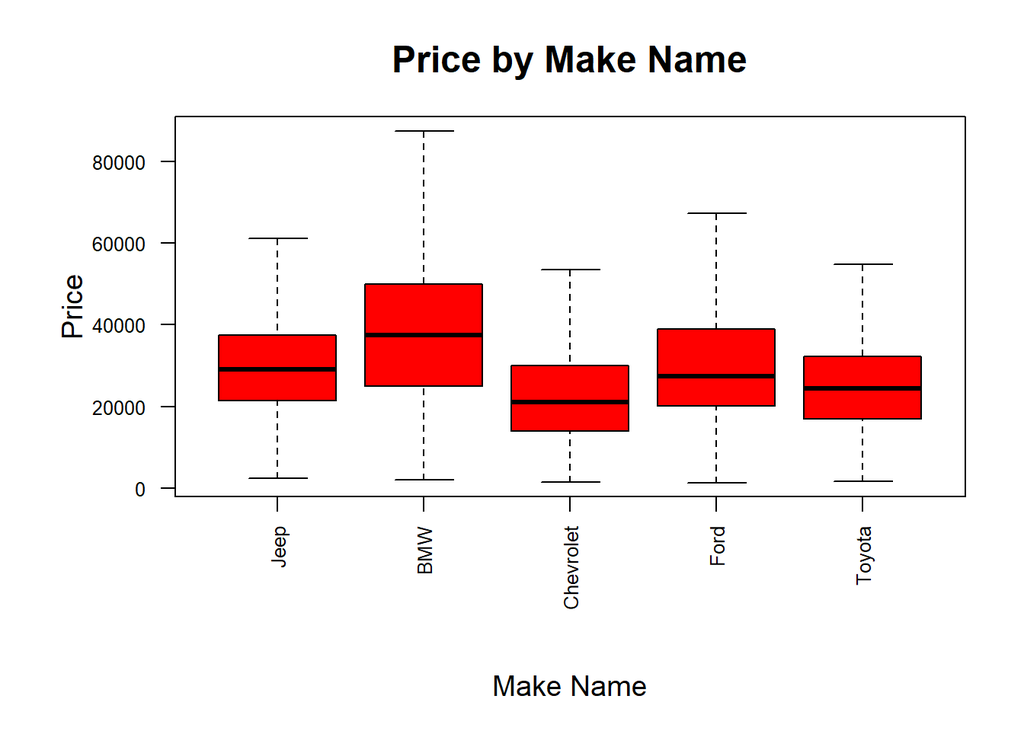

```r
# Plot 3: Price by Make Name
boxplot(price ~ factor(make_name, levels = unique(top_make_name$make_name)),
        data = top_make_name,
        main = "Price by Make Name",
        xlab = "",
        ylab = "Price",
        col = "red",
        las = 2,
        cex.axis = 0.8,
        cex.main = 1.5,
        cex.lab = 1.2,
        outline = FALSE)
mtext("Make Name", side = 1, line = 6, cex = 1.2)
```

```r
library(dplyr)
# Count the frequency of each car make
make_frequency <- cars.df %>%
  group_by(make_name) %>%
  summarise(frequency = n()) %>%
  arrange(desc(frequency))  # Sort in descending order

# Get the make with the largest frequency
largest_make <- make_frequency %>% slice(1)

# Print the result
cat("The most common manufacturer is:", largest_make$make_name, "with", largest_make$frequency, "vehicles.\n")
```

```
## The most common manufacturer is: Ford with 4095 vehicles.
```

What can we observe from the plots?

Histograms and bar plots:

-`body_type`: The most common car types are SUV, Sedan and Pickup Truck with the order named.

-`fuel_type`: Overwhelmingly most cars burn gasoline.

-`has_accidents`: The majority of cars had no accidents in the past.

-`price`: The majority of cars cost under 50,000.

-`seller_rating`: The ratings of the cars mostly fluctuate around 3.5-4.5.

-`year`: The year of manufacture of most vehicles is after 2015.

-`make_name` : The manufacturer with the most cars is Ford

Scatter plots:

-Price vs. Mileage: The third plot in the first row shows that as mileage increases, prices tend to decrease, which is common as cars with higher mileage are often older and have more wear, leading to lower resale values.

-Price vs. Year: The last plot in the first row shows the relationship between price and year. Newer cars (with recent years) tend to have higher prices, which makes sense as cars generally depreciate over time.

-Mileage vs. Year: The plot in the third row and last column might show a trend where older cars have higher mileage, reflecting accumulated usage over time.

-Highway_fuel_economy vs Year: The plot in the second row and last columns indicates that the most recent manufactured cars tend to have better highway fuel economy.

-Price vs fuel_type: Electric cars are more expensive (higher μ) due to high battery and technology costs, premium features, limited production scale, and positioning as luxury or flagship models.

-Price vs body_type: Pickup trucks are more expensive (higher μ) due to their larger size, powerful engines, heavy-duty construction for towing and hauling, and increasing demand for luxury and technology features in modern models.The cheapest (lower μ) is Hatchback.

-Price vs make_name: BMW is more expensive (higher μ) because it is positioned as a luxury brand, offering premium materials, advanced technology, performance-focused engineering, and a reputation for prestige and status compared to more mass-market brands like Jeep, Chevrolet (most affordable), Ford, and Toyota.

# Correlations between used car variables

```r
# Load necessary library
library(dplyr)

# Separate numerical and categorical variables
numerical_vars <- cars.df %>% select(daysonmarket, highway_fuel_economy, horsepower, mileage, price, seller_rating, year)
categorical_vars <- cars.df %>% select(body_type, fuel_type, has_accidents, is_new, make_name)

# Calculate the correlation matrix for numerical variables
cars.cor = cor(numerical_vars, use = "complete.obs")  # Use 'complete.obs' to handle NA values
correlation_matrix = round(cars.cor, 3)

# Display the correlation matrix
print(correlation_matrix)
```

```
##                      daysonmarket highway_fuel_economy horsepower mileage
## daysonmarket                1.000                0.015      0.027  -0.113
## highway_fuel_economy        0.015                1.000     -0.521  -0.144
## horsepower                  0.027               -0.521      1.000  -0.044
## mileage                    -0.113               -0.144     -0.044   1.000
## price                       0.095               -0.185      0.503  -0.437
## seller_rating              -0.065               -0.012      0.068  -0.032
## year                        0.042                0.153      0.027  -0.787
##                       price seller_rating   year
## daysonmarket          0.095        -0.065  0.042
## highway_fuel_economy -0.185        -0.012  0.153
## horsepower            0.503         0.068  0.027
## mileage              -0.437        -0.032 -0.787
## price                 1.000         0.121  0.348
## seller_rating         0.121         1.000  0.005
## year                  0.348         0.005  1.000
```

Some strong correlations! Let’s find the biggest (in absolute value):

```r
cars.cor[lower.tri(cars.cor,diag=TRUE)] = 0 # Why only upper tri part?
#Setting this part to 0 means only the upper triangle (above the diagonal) retains the correlation values. This removes duplicate values (since correlations are symmetric) and eliminates self-correlations (diagonal elements), which are always 1.

cars.cor.sorted = sort(abs(cars.cor),decreasing=T)
cars.cor.sorted[1]
```

```
## [1] 0.7873773
```

```r
vars.big.cor = arrayInd(which(abs(cars.cor)==cars.cor.sorted[1]),
                        dim(cars.cor)) # Note: arrayInd() is useful
colnames(numerical_vars)[vars.big.cor]
```

```
## [1] "mileage" "year"
```

Let’s find the second biggest correlation (in absolute value):

```r
cars.cor.sorted[2]
```

```
## [1] 0.5211418
```

```r
vars.big.cor = arrayInd(which(abs(cars.cor)==cars.cor.sorted[2]),
                        dim(cars.cor))
#arrayInd(...) then converts this linear index to row and column indices, using dim(pros.cor) to match the dimensions of pros.cor.
colnames(numerical_vars)[vars.big.cor]
```

```
## [1] "highway_fuel_economy" "horsepower"
```

## *Step 4: Perform Hypothesis testing using the initial inferences from the previous step*

Let’s state some questions based on our visualizations and check if they are valid or not.

1.Is SUV the most common `body_type`? Does `SUV/Crossover` type constitute more than 50% of the entire car data set?

2.The wear and tear of the cars is a very significant parameter to assess the value of them. Let’s examine if cars with has_accidents=True and Year<=2015 tend to have lower prices that cars with has_accidents=False and Year>2015.

3.Regarding BMW’s expensive cars, one can assume that it has the cars with higher quality, hence higher seller ratings for the other most common cars manufacturers (i.e. Jeep., Chevrolet, Ford, Toyota). Let’s examine if that states.

4.Does over 95% of cars have less than 150,000 kilometers? For the histogram of mileage one can observe that almost all cars have less than 150,000 kilometers.

In these cases, the code performs a t-test with the assumption of unequal variances (var.equal = FALSE), which is a key indicator that the population variances are unknown and not assumed to be the same. This makes the t-test more flexible in handling real-world data where these assumptions may not hold. The t-distribution also adjusts for the added uncertainty from estimating the population standard deviation.

```r
#1.
# Step 1: Create a binary variable for SUV
cars.df$suv_binary <- ifelse(cars.df$body_type == "SUV / Crossover", 1, 0)

# Step 2: Perform a one-sample t-test
# Testing if the mean frequency of SUVs is significantly greater than 0.5 (50%)
t.test(cars.df$suv_binary, mu = 0.5, alternative = "greater")
```

```
##
##  One Sample t-test
##
## data:  cars.df$suv_binary
## t = 3.6794, df = 28314, p-value = 0.0001171
## alternative hypothesis: true mean is greater than 0.5
## 95 percent confidence interval:
##  0.506044      Inf
## sample estimates:
## mean of x
## 0.5109306
```

With a p-value of 0.0001171, this result is statistically significant at the 0.05 level, meaning there’s strong evidence to reject the null hypothesis. This indicates that the mean proportion of SUVs in the dataset is significantly greater than 0.5, or 50%.

```r
#2.
# Filter data for Group 1 and Group 2
group1_prices <- cars.df$price[cars.df$has_accidents == "True" & cars.df$year <= 2015]
group2_prices <- cars.df$price[cars.df$has_accidents == "False" & cars.df$year > 2015]

# Perform Welch's t-test
t_test <- t.test(group1_prices, group2_prices, alternative = "less")

# Display results
t_test
```

```
##
##  Welch Two Sample t-test
##
## data:  group1_prices and group2_prices
## t = -61.937, df = 5320.8, p-value < 2.2e-16
## alternative hypothesis: true difference in means is less than 0
## 95 percent confidence interval:
##       -Inf -16981.28
## sample estimates:
## mean of x mean of y
##  10982.30  28426.94
```

The test provides strong evidence that cars with accidents (Group 1) and older manufacturing years (≤ 2015) tend to have significantly lower prices than cars with no accidents (Group 2) and recent manufacturing years (> 2015).

```r
#3
# Filter seller ratings by manufacturer
bmw_ratings <- cars.df$seller_rating[cars.df$make_name == "BMW"]
other_ratings <- cars.df$seller_rating[cars.df$make_name %in% c("Jeep", "Chevrolet", "Ford", "Toyota")]

# Compute the average of the other four manufacturers
average_other <- mean(other_ratings, na.rm = TRUE)

# Perform one-sample t-test
t_test <- t.test(bmw_ratings, mu = average_other, alternative = "greater")

# Display results
t_test
```

```
##
##  One Sample t-test
##
## data:  bmw_ratings
## t = 9.5622, df = 1981, p-value < 2.2e-16
## alternative hypothesis: true mean is greater than 3.9966
## 95 percent confidence interval:
##  4.088472      Inf
## sample estimates:
## mean of x
##   4.10757
```

The test provides strong evidence that BMW’s average seller rating (4.11) s significantly higher than the average seller rating of the other four manufacturers combined (3.9966)

```r
#4.
# Step 1: Create a binary variable for cars with less than 100,000 kilometers
cars.df$less_than_100k <- ifelse(cars.df$mileage < 150000, 1, 0)

# Step 2: Perform a one-sample t-test
t_test_result <- t.test(cars.df$less_than_100k, mu = 0.95, alternative = "greater")

# Display the result
print(t_test_result)
```

```
##
##  One Sample t-test
##
## data:  cars.df$less_than_100k
## t = 10.811, df = 28314, p-value < 2.2e-16
## alternative hypothesis: true mean is greater than 0.95
## 95 percent confidence interval:
##  0.9603829       Inf
## sample estimates:
## mean of x
## 0.9622462
```

This extremely low p-value suggests strong evidence against the null hypothesis. You can reject the null hypothesis, indicating that the mean of the binary variable (the proportion of cars with less than 150,000 kilometers) is significantly greater than 0.95.

## *Step 5: Model Building step*

The linear model is arguably the **most widely used** statistical model, has a place in nearly every application domain of statistics

Given response $Y$ and predictors $X_1,\ldots,X_p$, in a **linear regression model**, we posit:

$$Y = \beta_0 + \beta_1 X_1 + \ldots + \beta_p X_p + \epsilon,
\quad \text{where $\epsilon \sim N(0,\sigma^2)$}$$

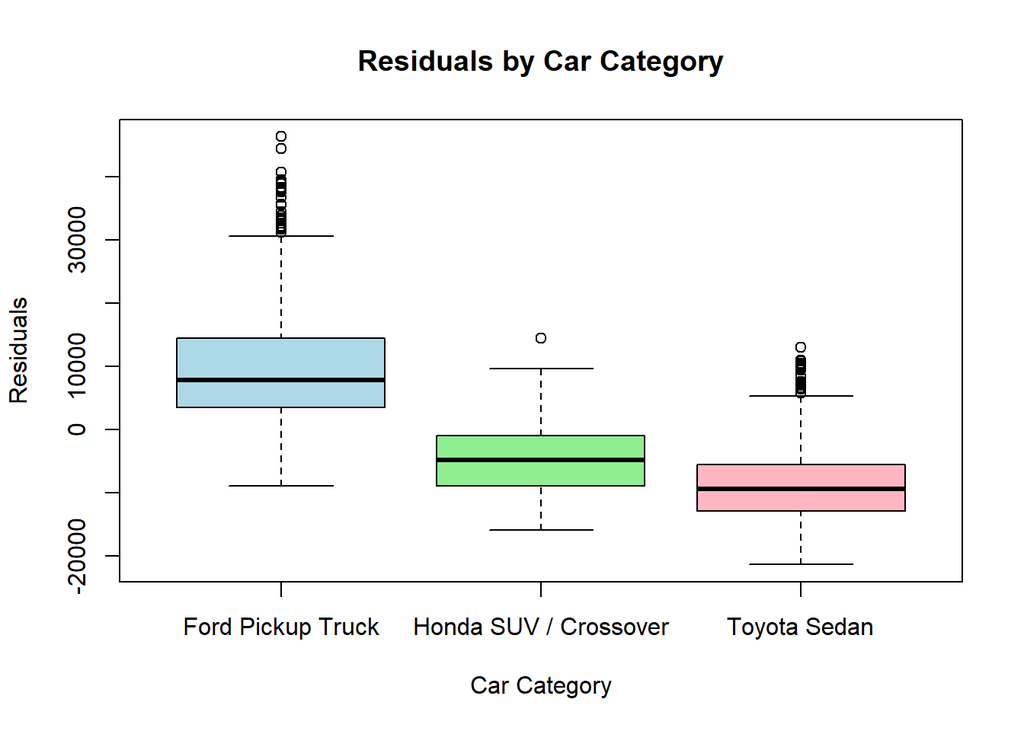

```r
# Step 1: Calculate car age
cars.df$car_age <- 2024 - cars.df$year

# Step 2: Select categories and filter data
selected_categories <- c("Toyota Sedan", "Honda SUV / Crossover", "Ford Pickup Truck") # Update with actual category names
cars.df$category <- paste(cars.df$make_name, cars.df$body_type)
cars_subset <- subset(cars.df, category %in% selected_categories)

# Step 3: Build the linear model
lm_model <- lm(price ~ mileage + car_age, data = cars_subset)

# Step 4: Calculate residuals and add to the data frame
cars_subset$residuals <- resid(lm_model)

# Step 5: Plot residuals by category
boxplot(residuals ~ category, data = cars_subset,
        main = "Residuals by Car Category",
        xlab = "Car Category",
        ylab = "Residuals",
        col = c("lightblue", "lightgreen", "lightpink"))
```

Interpretation:

The boxplot above displays the residuals of the linear regression model for each selected car category.

## *Step 6: Residual Analysis of Model*

1.I will start with a null model (no predictors), and calculate the adjusted $R^2$ for this baseline model.

2.I will add each variable one at a time and check the adjusted $R^2$ for each resulting model.

4.I will repeat by adding additional variables one at a time, selecting the variable that offers the highest adjusted $R^2$ improvement until no significant improvement is achieved.

```r
# Step 1: Define a null model and a full model
null_model <- lm(price ~ 1, data = cars.df) # model with no predictors
full_model <- lm(price ~ mileage: + car_age + horsepower , data = cars.df) # model with all predictors, note that I chose as predictors only variables that have absolut correlation with price > 0.5

# Step 2: Use stepwise selection with forward direction based on adjusted R-squared
forward_model <- step(null_model,
                      scope = list(lower = null_model, upper = full_model),
                      direction = "forward",
                      k = log(nrow(cars.df))) # k = log(n) is used for BIC(Bayesian Information Criterion), which balances fit and complexity
```

```
## Start:  AIC=568786
## price ~ 1
##
##                   Df  Sum of Sq        RSS    AIC
## + horsepower       1 3.7998e+12 1.1193e+13 560520
## + mileage:car_age  1 2.1823e+12 1.2810e+13 564342
## <none>                          1.4993e+13 568786
##
## Step:  AIC=560520.1
## price ~ horsepower
##
##                   Df  Sum of Sq        RSS    AIC
## + mileage:car_age  1 1.9011e+12 9.2917e+12 555260
## <none>                          1.1193e+13 560520
##
## Step:  AIC=555259.5
## price ~ horsepower + mileage:car_age
```

```r
# Print the summary of the forward selection model
summary(forward_model)
```

```
##
## Call:
## lm(formula = price ~ horsepower + mileage:car_age, data = cars.df)
##
## Residuals:
##     Min      1Q  Median      3Q     Max
##  -48112   -7185   -1445    4615 1357437
##
## Coefficients:
##                   Estimate Std. Error t value Pr(>|t|)
## (Intercept)      4.595e+02  3.466e+02   1.326    0.185
## horsepower       1.352e+02  1.306e+00 103.544   <2e-16 ***
## mileage:car_age -1.165e-02  1.531e-04 -76.109   <2e-16 ***
## ---
## Signif. codes:  0 '***' 0.001 '**' 0.01 '*' 0.05 '.' 0.1 ' ' 1
##
## Residual standard error: 18120 on 28312 degrees of freedom
## Multiple R-squared:  0.3802, Adjusted R-squared:  0.3802
## F-statistic:  8685 on 2 and 28312 DF,  p-value: < 2.2e-16
```

# Residual Analysis

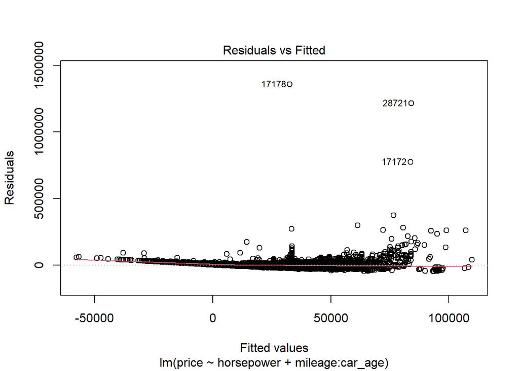

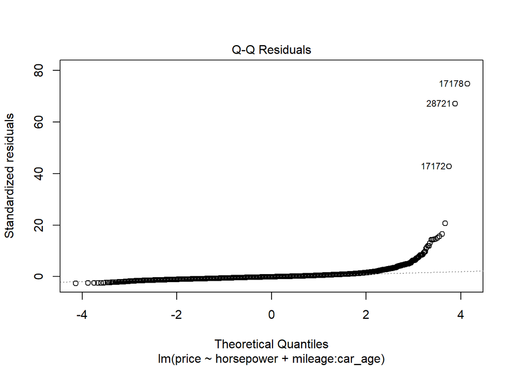

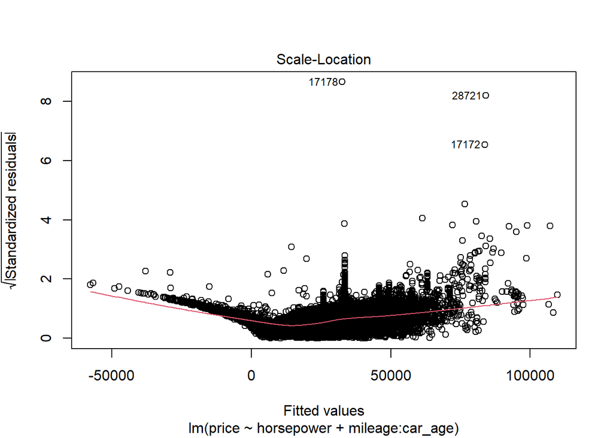

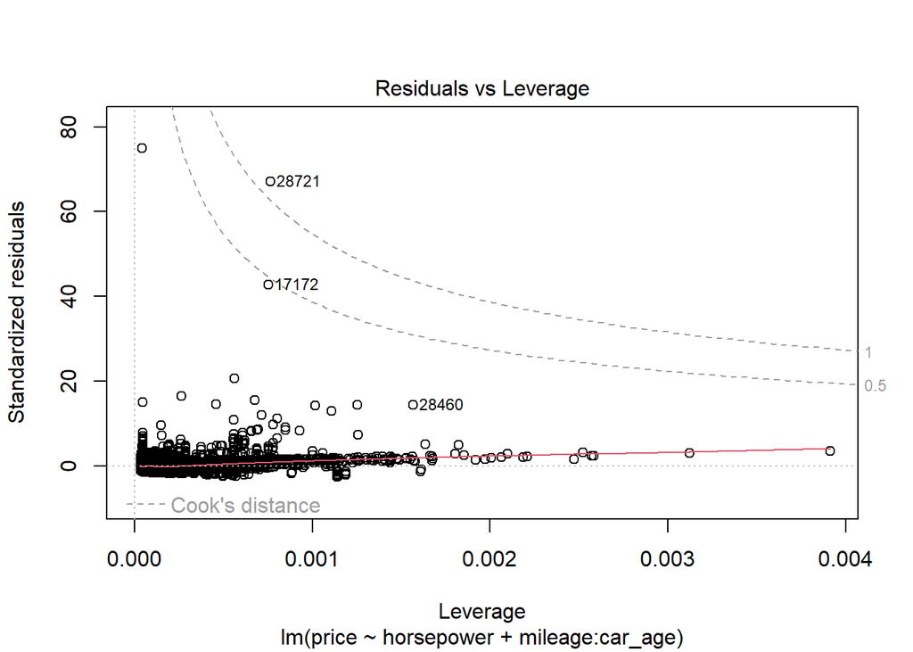

```r
# Plot residuals to check assumptions

plot(forward_model)
```